## index.Rmd ————————-

title: Testing ImpressJS author: Ramnath Vaidyanathan mode : selfcontained framework: impressjs github: user: ramnathv repo: slidify twitter: text: “Slidify with impress.js!” url: lib: ../libraries

— .slide x:-1000 y:-1500

Aren’t you just **bored** with all those slides-based presentations?

— .slide x:0 y:-1500

Don’t you think that presentations given **in modern browsers** shouldn’t **copy the limits** of ‘classic’ slide decks?

— .slide x:1000 y:-1500

Would you like to **impress your audience** with **stunning visualization** of your talk?

— #title x:0 y:0 scale:4

then you should try # impressjs^* ^* no rhyme intended

— #its x:850 y:3000 rot:45 scale:5

It’s a **presentation tool**  
inspired by the idea behind prezi.com  
and based on the **power of CSS3 transforms and transitions** in modern browsers.

— #big x:3500 y:2100 rot:180 scale:6

visualize your **big** thoughts

— #ghablame x:2825 y:2325 z:-3000 rot:300 scale:1

and **tiny** ideas

— #ing x:3500 y:-850 rot:270 scale:6 by **positioning**, **rotating** and **scaling** them on an infinite canvas

— #imagination x:6700 y:-300 scale:6

the only **limit** is your **imagination**

— #source x:6300 y:2000 rot:20 scale:4

want to know more?

[use the source](http://github.com/bartaz/impress.js), Luke

— #one-more-thing x:6000 y:4000 scale:2

one more thing…

— #its-in-3d x:6200 y:4300 z:-100 rotx:-40 roty:-10 scale:2

have you noticed it’s in **3D***?

* beat that, prezi ;)

— #rstats x:-1000 y:5000

```r
library(ggplot2)
qplot(wt, mpg, data = mtcars)
```

— x:-1500 y:5500

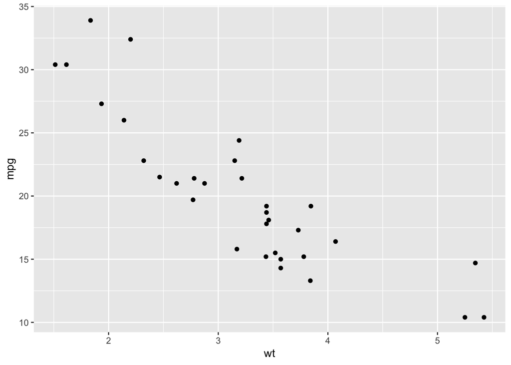